# Análisis de componentes principales: cerveza artesanal de maíz morado y quinua

Author

Bryan Chavez Velaisosa

# 1 Project Setup

```r
source('https://inkaverse.com/setup.r')
```

# 2 Data import

```r
gs <- "https://docs.google.com/spreadsheets/d/1nhsWjlUSZ3pRI3AxDg4MsXkxKMixxkaHPeB_lV3cG30/edit?gid=1278491723#gid=1278491723" %>%
  as_sheets_id()

fb <- gs %>%
  range_read(ss = .,sheet = "cerveza") %>%
  mutate(across(c(1:rep), ~ as.factor(.)))

fb %>% str()
```

```
tibble [54 × 12] (S3: tbl_df/tbl/data.frame)
 $ plots      : Factor w/ 54 levels "101","102","103",..: 1 2 3 4 5 6 7 8 9 10 ...
 $ ntreat     : Factor w/ 18 levels "1","2","3","4",..: 1 2 3 4 5 6 7 8 9 10 ...
 $ tratamiento: Factor w/ 18 levels "P1T1t1","P1T1t2",..: 1 2 3 4 5 6 7 8 9 10 ...
 $ proporcion : Factor w/ 2 levels "M40Q60","M60Q40": 1 1 1 1 1 1 1 1 1 2 ...
 $ temperatura: Factor w/ 3 levels "100","110","120": 1 1 1 2 2 2 3 3 3 1 ...
 $ tiempo     : Factor w/ 3 levels "105","115","125": 1 2 3 1 2 3 1 2 3 1 ...
 $ rep        : Factor w/ 3 levels "1","2","3": 1 1 1 1 1 1 1 1 1 1 ...
 $ brix       : num [1:54] 7.33 7.54 8.34 6.52 7.53 8.54 6.36 7.36 7.35 7.45 ...
 $ ph         : num [1:54] 3.7 4.37 4.6 4.78 4.56 ...
 $ densidad   : num [1:54] 1.01 1.01 1.01 1.01 1.01 ...
 $ alcohol    : num [1:54] 4.6 5.77 3.6 5.88 4.96 ...
 $ acidez     : num [1:54] 0.366 0.254 0.214 0.39 0.26 0.368 0.28 0.34 0.31 0.22 ...
```

# 3 Modelo

$$alcohol = P + T + t + P*T + P*t + T*t + P*T*t$$

```r
av  <-  aov(alcohol ~ proporcion*temperatura*tiempo, fb)

anova(av)
```

```
Analysis of Variance Table

Response: alcohol
                              Df  Sum Sq Mean Sq  F value                Pr(>F)
proporcion                     1  0.1148  0.1148   4.4693                0.0415
temperatura                    2  2.6773  1.3386  52.1066 0.0000000000235093837
tiempo                         2 14.2114  7.1057 276.5896 < 0.00000000000000022
proporcion:temperatura         2  1.1498  0.5749  22.3786 0.0000004832536366282
proporcion:tiempo              2  8.5332  4.2666 166.0786 < 0.00000000000000022
temperatura:tiempo             4  2.5496  0.6374  24.8108 0.0000000006396021223
proporcion:temperatura:tiempo  4  6.5989  1.6497  64.2156 0.0000000000000006894
Residuals                     36  0.9249  0.0257

proporcion                    *
temperatura                   ***
tiempo                        ***
proporcion:temperatura        ***
proporcion:tiempo             ***
temperatura:tiempo            ***
proporcion:temperatura:tiempo ***
Residuals
---
Signif. codes:  0 '***' 0.001 '**' 0.01 '*' 0.05 '.' 0.1 ' ' 1
```

```r
mc <- emmeans(av, ~ temperatura*tiempo) %>%
  as.data.frame()

mc
```

```
 temperatura tiempo   emmean         SE df lower.CL upper.CL
 100         105    4.816667 0.06543487 36 4.683959 4.949375
 110         105    5.768333 0.06543487 36 5.635625 5.901041
 120         105    5.300833 0.06543487 36 5.168125 5.433541
 100         115    4.613000 0.06543487 36 4.480292 4.745708
 110         115    4.663333 0.06543487 36 4.530625 4.796041
 120         115    4.000833 0.06543487 36 3.868125 4.133541
 100         125    4.213333 0.06543487 36 4.080625 4.346041
 110         125    4.248000 0.06543487 36 4.115292 4.380708
 120         125    3.763333 0.06543487 36 3.630625 3.896041

Results are averaged over the levels of: proporcion
Confidence level used: 0.95
```

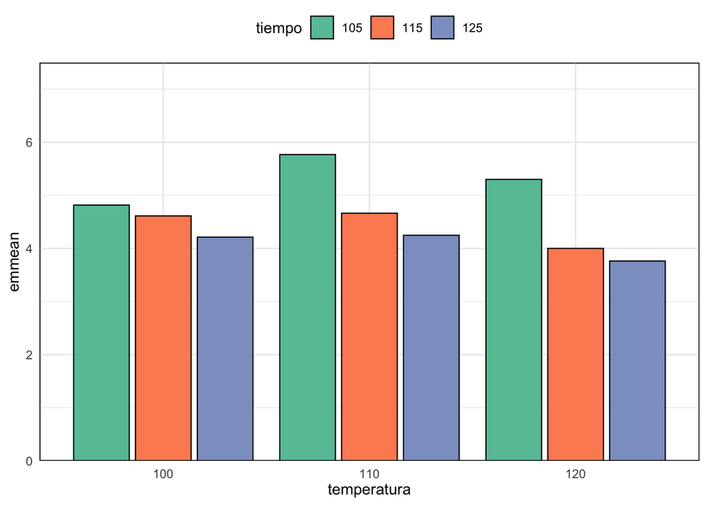

```r
plot_smr(mc
         , type = "bar"
         , y = "emmean"
         , x = "temperatura"
         , group = "tiempo")
```

# 4 Multivariate

```r
library(factoextra)

dtx <- fb %>%
  dplyr::select(c("proporcion", "temperatura", "tiempo", "brix", "ph", "densidad", "alcohol", "acidez")) %>%
  group_by(proporcion, temperatura, tiempo) %>%
  summarise(across(where(is.numeric), ~ mean(.x, na.rm = TRUE))) %>%
  unite("rowname", c("proporcion", "temperatura", "tiempo"), remove = F, sep = "-") %>%
  column_to_rownames() %>%
  as.data.frame()

str(dtx)
```

```
'data.frame':   18 obs. of  8 variables:
 $ proporcion : Factor w/ 2 levels "M40Q60","M60Q40": 1 1 1 1 1 1 1 1 1 2 ...
 $ temperatura: Factor w/ 3 levels "100","110","120": 1 1 1 2 2 2 3 3 3 1 ...
 $ tiempo     : Factor w/ 3 levels "105","115","125": 1 2 3 1 2 3 1 2 3 1 ...
 $ brix       : num  7.39 7.44 8.44 6.61 7.61 ...
 $ ph         : num  3.6 4.39 4.57 4.78 4.63 ...
 $ densidad   : num  1.01 1.01 1.01 1.01 1.01 ...
 $ alcohol    : num  4.18 5.66 3.57 5.81 4.86 ...
 $ acidez     : num  0.357 0.251 0.213 0.389 0.268 ...
```

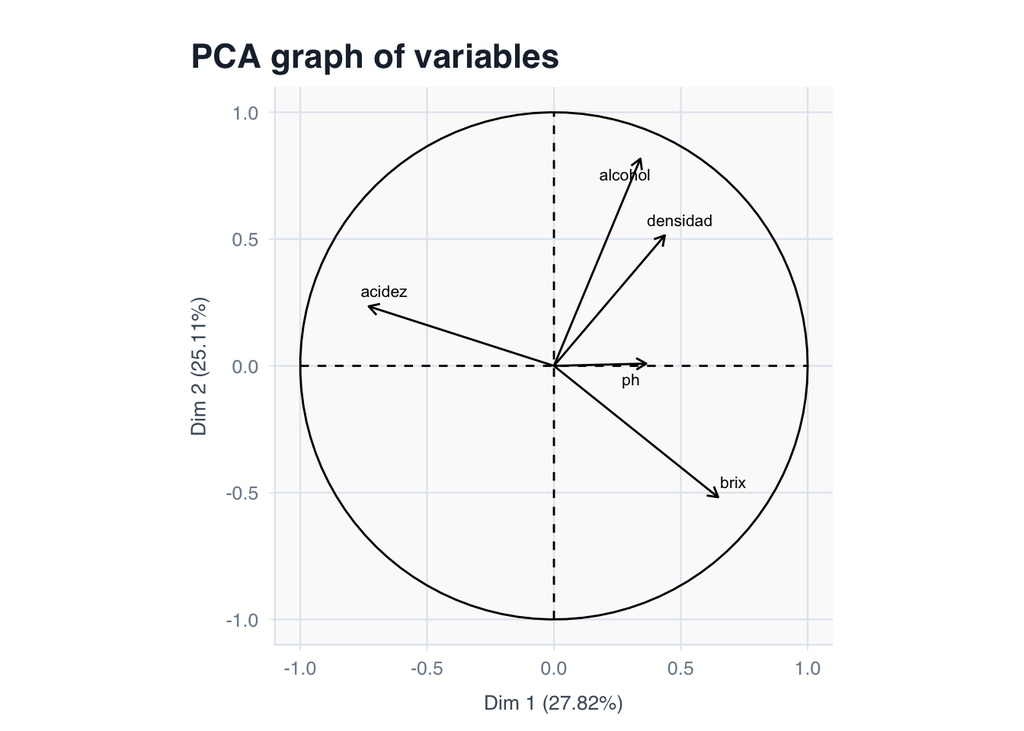

```r
mv <- dtx %>%
  PCA(scale.unit = T
      , graph = F
      , quali.sup = c(1, 2, 3))

var <- mv %>%
  plot.PCA(choix = c("var"), cex=0.7)

var
```

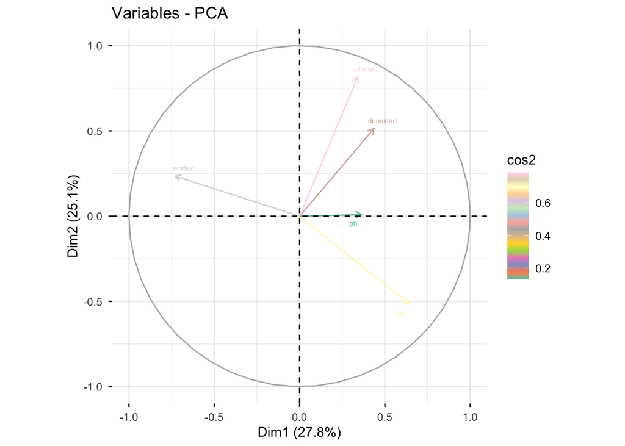

```r
cos <- mv %>%
  fviz_pca_var(col.var = "cos2"
               , gradient.cols = inti:::paleta()
               , repel = TRUE
               , labelsize = 2)
cos
```

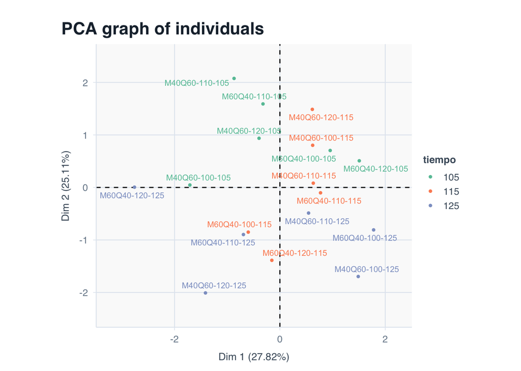

```r
ind <- mv %>%
  plot.PCA(choix = c("ind")
           , cex = 0.7
           , label = "ind"
           , invisible = "quali"
           , col.hab = inti:::paleta()
           , habillage = 3
           )

ind
```

```r
pcainfo <- factoextra::get_pca(mv); pcainfo
```

```
Principal Component Analysis Results for variables
 ===================================================
  Name       Description
1 "$coord"   "Coordinates for the variables"
2 "$cor"     "Correlations between variables and dimensions"
3 "$cos2"    "Cos2 for the variables"
4 "$contrib" "contributions of the variables"
```

```r
pcainfo$cor %>% kable(caption = "Variable correlations")
```

Variable correlations

|  | Dim.1 | Dim.2 | Dim.3 | Dim.4 | Dim.5 |
| --- | --- | --- | --- | --- | --- |
| brix | 0.6469819 | -0.5179563 | -0.2739810 | 0.3341851 | 0.3555143 |
| ph | 0.3638931 | 0.0088608 | 0.7988404 | 0.4279388 | -0.2150018 |
| densidad | 0.4368850 | 0.5145218 | -0.6017683 | 0.2654940 | -0.3343452 |
| alcohol | 0.3407935 | 0.8168850 | 0.2252534 | -0.1340043 | 0.3845288 |
| acidez | -0.7299785 | 0.2346535 | -0.0996014 | 0.6058511 | 0.1873317 |

```r
pcainfo$contrib %>% kable(caption = "Variable Contribution")
```

Variable Contribution

|  | Dim.1 | Dim.2 | Dim.3 | Dim.4 | Dim.5 |
| --- | --- | --- | --- | --- | --- |
| brix | 30.094993 | 21.3690713 | 6.6079098 | 14.884455 | 27.043571 |
| ph | 9.520456 | 0.0062538 | 56.1750101 | 24.407423 | 9.890857 |
| densidad | 13.722847 | 21.0866213 | 31.8773148 | 9.394379 | 23.918838 |
| alcohol | 8.350117 | 53.1522071 | 4.4664850 | 2.393294 | 31.637897 |
| acidez | 38.311588 | 4.3858465 | 0.8732803 | 48.920449 | 7.508837 |

```r
pcainfo$cos2 %>% kable(caption = "Variable Cos2")
```

Variable Cos2

|  | Dim.1 | Dim.2 | Dim.3 | Dim.4 | Dim.5 |
| --- | --- | --- | --- | --- | --- |
| brix | 0.4185856 | 0.2682787 | 0.0750656 | 0.1116797 | 0.1263904 |
| ph | 0.1324182 | 0.0000785 | 0.6381459 | 0.1831316 | 0.0462258 |
| densidad | 0.1908685 | 0.2647327 | 0.3621251 | 0.0704871 | 0.1117867 |
| alcohol | 0.1161402 | 0.6673012 | 0.0507391 | 0.0179571 | 0.1478624 |
| acidez | 0.5328686 | 0.0550623 | 0.0099204 | 0.3670555 | 0.0350932 |

```r
psych::KMO(dtx[4:8])
```

```
Kaiser-Meyer-Olkin factor adequacy
Call: psych::KMO(r = dtx[4:8])
Overall MSA =  0.37
MSA for each item =
    brix       ph densidad  alcohol   acidez
    0.37     0.36     0.34     0.34     0.48
```

```r
psych::cortest.bartlett(cor(dtx[4:8]), n = nrow(dtx))
```

```
$chisq
[1] 5.263242

$p.value
[1] 0.8729138

$df
[1] 10
```

```r
dimdesc(mv, axes = 1:3)
```

```
$Dim.1

Link between the variable and the continuous variables (R-square)
=================================================================================
       correlation      p.value  n
brix     0.6469819 0.0037069602 18
acidez  -0.7299785 0.0005835349 18

$Dim.2

Link between the variable and the continuous variables (R-square)
=================================================================================
         correlation       p.value  n
alcohol    0.8168850 0.00003515454 18
densidad   0.5145218 0.02890977582 18
brix      -0.5179563 0.02767700312 18

Link between the variable and the categorical variable (1-way anova)
=============================================
         R2     p.value
0.509401835 0.004791201

Link between variable and the categories of the categorical variables
================================================================
             Estimate     p.value
tiempo=105  0.9768747 0.006435010
tiempo=125 -0.9819779 0.006086772

$Dim.3

Link between the variable and the continuous variables (R-square)
=================================================================================
         correlation       p.value  n
ph         0.7988404 0.00007015713 18
densidad  -0.6017683 0.00823796004 18
```

```r
cls <- mv %>% HCPC(nb.clust = 3, graph = FALSE)

map <- \() {plot.HCPC(cls, choice = "map", draw.tree = FALSE)}

cls$call$t$tree
```

```
Call:
flashClust::hclust(d = dissi, method = method, members = weight)

Cluster method   : ward
Distance         : euclidean
Number of objects: 18
```

```r
cls$data.clust %>%
  kable(caption = "Cluster membership of each individual")
```

Cluster membership of each individual

|  | proporcion | temperatura | tiempo | brix | ph | densidad | alcohol | acidez | clust |
| --- | --- | --- | --- | --- | --- | --- | --- | --- | --- |
| M40Q60-100-105 | M40Q60 | 100 | 105 | 7.386667 | 3.600000 | 1.012767 | 4.183333 | 0.3570000 | 1 |
| M40Q60-100-115 | M40Q60 | 100 | 115 | 7.436667 | 4.390000 | 1.011333 | 5.656667 | 0.2513333 | 3 |
| M40Q60-100-125 | M40Q60 | 100 | 125 | 8.443333 | 4.570000 | 1.012833 | 3.570000 | 0.2130000 | 2 |
| M40Q60-110-105 | M40Q60 | 110 | 105 | 6.606667 | 4.776667 | 1.011867 | 5.810000 | 0.3893333 | 3 |
| M40Q60-110-115 | M40Q60 | 110 | 115 | 7.606667 | 4.626667 | 1.011700 | 4.860000 | 0.2680000 | 3 |
| M40Q60-110-125 | M40Q60 | 110 | 125 | 8.580000 | 4.729333 | 1.011000 | 4.762667 | 0.3626667 | 2 |
| M40Q60-120-105 | M40Q60 | 120 | 105 | 6.523333 | 4.568333 | 1.011833 | 4.901667 | 0.2753333 | 3 |
| M40Q60-120-115 | M40Q60 | 120 | 115 | 7.420000 | 4.548333 | 1.021000 | 4.548333 | 0.3416667 | 3 |
| M40Q60-120-125 | M40Q60 | 120 | 125 | 7.503333 | 4.516667 | 1.003833 | 3.510000 | 0.3153333 | 2 |
| M60Q40-100-105 | M60Q40 | 100 | 105 | 7.366667 | 4.466667 | 1.012233 | 5.450000 | 0.2230000 | 3 |
| M60Q40-100-115 | M60Q40 | 100 | 115 | 7.600000 | 4.739333 | 1.011200 | 3.569333 | 0.3546667 | 2 |
| M60Q40-100-125 | M60Q40 | 100 | 125 | 8.706667 | 4.893333 | 1.010933 | 4.856667 | 0.2686667 | 2 |
| M60Q40-110-105 | M60Q40 | 110 | 105 | 6.673333 | 4.760000 | 1.010867 | 5.726667 | 0.3220000 | 3 |
| M60Q40-110-115 | M60Q40 | 110 | 115 | 7.556667 | 4.673333 | 1.012933 | 4.466667 | 0.2550000 | 3 |
| M60Q40-110-125 | M60Q40 | 110 | 125 | 6.660000 | 4.780000 | 1.007500 | 3.733333 | 0.2493333 | 2 |
| M60Q40-120-105 | M60Q40 | 120 | 105 | 7.600000 | 4.750000 | 1.010667 | 5.700000 | 0.2106667 | 3 |
| M60Q40-120-115 | M60Q40 | 120 | 115 | 7.493333 | 4.503333 | 1.010000 | 3.453333 | 0.2533333 | 2 |
| M60Q40-120-125 | M60Q40 | 120 | 125 | 6.583333 | 4.566667 | 1.007333 | 4.016667 | 0.4386667 | 2 |

```r
cls$desc.var$quanti %>%
  kable(caption = "Quantitative variables characterizing each cluster")
```

Quantitative variables characterizing each cluster

|  | v.test | Mean in category | Overall mean | sd in category | Overall sd | p.value | n |
| --- | --- | --- | --- | --- | --- | --- | --- |
| ph | -3.626344 | 3.6 | 4.581037 | 0 | 0.2705306 | 0.0002875 | 1 |

|  | v.test | Mean in category | Overall mean | sd in category | Overall sd | p.value | n |
| --- | --- | --- | --- | --- | --- | --- | --- |
| densidad | -2.131549 | 1.009329 | 1.011213 | 0.0027186 | 0.0032592 | 0.0330439 | 8 |
| alcohol | -3.008794 | 3.934000 | 4.598630 | 0.5316716 | 0.8146231 | 0.0026229 | 8 |

|  | v.test | Mean in category | Overall mean | sd in category | Overall sd | p.value | n |
| --- | --- | --- | --- | --- | --- | --- | --- |
| alcohol | 3.223715 | 5.235556 | 4.59863 | 0.5083956 | 0.8146231 | 0.0012654 | 9 |

```r
cls$desc.var$category%>%
  kable(caption = "Categorical variables significantly by cluster")
```

Categorical variables significantly by cluster

|  | Cla/Mod | Mod/Cla | Global | p.value | v.test |
| --- | --- | --- | --- | --- | --- |
| tiempo=125 | 100 | 75 | 33.33333 | 0.0015083 | 3.173083 |
| tiempo=105 | 0 | 0 | 33.33333 | 0.0113122 | -2.532903 |

|  | Cla/Mod | Mod/Cla | Global | p.value | v.test |
| --- | --- | --- | --- | --- | --- |
| tiempo=125 | 0 | 0 | 33.33333 | 0.0045249 | -2.839044 |

```r
table(cls$data.clust$clust) %>%
  kable(caption = "Number of individuals assigned to each cluster")
```

Number of individuals assigned to each cluster

| Var1 | Freq |
| --- | --- |
| 1 | 1 |
| 2 | 8 |
| 3 | 9 |

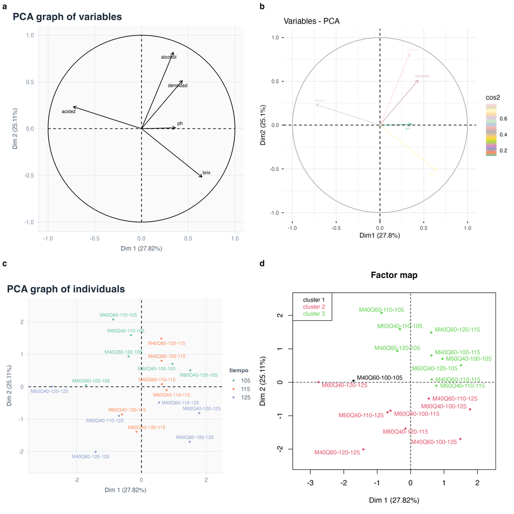

```r
dir.create("manuscript", showWarnings = FALSE)

plot <- list(var, cos, ind, map) %>%
  plot_grid(plotlist = ., ncol = 2, labels = "auto") %>%
  ggsave(plot = ., "manuscript/multivariate.jpg", units = "cm"
                , width = 30, height = 30)

plot %>% include_graphics()
```

# 5 Interpretación

**Adecuación de los datos.** Las cinco variables casi no se correlacionan entre sí (|r| ≤ 0,30). La prueba de Bartlett no es significativa (p = 0,87) y el KMO es 0,37, menor que 0,5. Por eso el PCA resume poca información y cada dimensión explica una parte parecida de la varianza.

**Varianza explicada.** Tres dimensiones tienen valor propio mayor que 1: Dim.1 (27,8 %), Dim.2 (25,1 %) y Dim.3 (22,7 %). El plano Dim1–Dim2 explica el 52,9 %, y las tres primeras el 75,6 %.

**Dim.1** contrapone la acidez total (r = −0,73; contribución 38,3 %) a los °Brix (r = 0,65; 30,1 %): los tratamientos con más sólidos solubles residuales tienen menor acidez.

**Dim.2** está definida por el grado alcohólico (r = 0,82; 53,2 %), asociado a la densidad (r = 0,51) y opuesto a los °Brix (r = −0,52). Es la única dimensión donde un factor es significativo: el **tiempo de tostado**. Con 105 min los tratamientos se ubican hacia más alcohol y con 125 min hacia menos (p < 0,01). Esto coincide con el ANOVA, donde el tiempo fue el efecto más fuerte sobre el alcohol.

**Dim.3** está definida por el pH (r = 0,80), opuesto a la densidad (r = −0,60).

**Clusters.** Con tres grupos: el cluster 1 tiene solo M40Q60-100-105, por su pH bajo (3,6); el cluster 2 agrupa principalmente los tratamientos de 125 min, con menor grado alcohólico (3,9 %); y el cluster 3 los de 105 y 115 min, con mayor grado alcohólico (5,2 %). La proporción de maltas y la temperatura no definieron ningún grupo.

**Conclusión.** El tiempo de tostado es el factor que más separa los tratamientos: un tostado más corto produjo cervezas con más alcohol. Como las variables están poco correlacionadas, el PCA tiene un poder de síntesis limitado, y las diferencias deben confirmarse con el ANOVA de cada variable.

# 6 References

Díaz Aranda, D. L., & Lucero Cueva, L. J. (2022). Cerveza artesanal elaborado con maíz morado (Zea mays) y quinua (Chenopodium quinoa) tipo malteado, tostados a diferentes tiempos y temperaturas [Tesis de pregrado, Universidad Nacional de Jaén]. https://repositorio.unj.edu.pe/handle/UNJ/447